# Analyse de données - TD 2

Outils de surveillance et analyses statistiques

INTECHMER - CT3 GEM

## Analyse en Composantes Principales (ACP)

### Données `iris`

Nous utilisons pour exemple les données `iris`, déjà présentes dans R. Elle regroupe les mesures (longueur et largeur des sépales et des pétales) de 150 iris, de trois espèces différentes (*setosa*, *versicolor* et *virginica*). Les voici présentées ci-dessous

```r
library(tidyverse)
library(DT)
datatable(iris)
```

|  | Sepal.Length | Sepal.Width | Petal.Length | Petal.Width | Species |
| --- | --- | --- | --- | --- | --- |
| 1 | 5.1 | 3.5 | 1.4 | 0.2 | setosa |
| 2 | 4.9 | 3 | 1.4 | 0.2 | setosa |
| 3 | 4.7 | 3.2 | 1.3 | 0.2 | setosa |
| 4 | 4.6 | 3.1 | 1.5 | 0.2 | setosa |
| 5 | 5 | 3.6 | 1.4 | 0.2 | setosa |
| 6 | 5.4 | 3.9 | 1.7 | 0.4 | setosa |
| 7 | 4.6 | 3.4 | 1.4 | 0.3 | setosa |
| 8 | 5 | 3.4 | 1.5 | 0.2 | setosa |
| 9 | 4.4 | 2.9 | 1.4 | 0.2 | setosa |
| 10 | 4.9 | 3.1 | 1.5 | 0.1 | setosa |

[output cut: 140 more lines]

Pour réaliser l’ACP, nous utilisons le package [`FactoMineR`](http://factominer.free.fr/index_fr.html), très complet et bien documenté. Il existe d’autres versions, mais moins intéressantes à utiliser.

```r
library(FactoMineR)
```

### Application de la méthode sur les données

Pour mettre en oeuvre une ACP, il suffit d’utiliser la fonction `PCA()` (pour *Principal Components Analysis*), qui renvoie un objet complxe, comme nous le verrons plus tard. Nous devons bien évidemment supprimer la variable `Species`. L’opion `graph = FALSE` évite la création de deux graphiques (cercle des corrélations et premier plan factoriel, que nous créérons par la suite).

```r
acp = PCA(iris[,-5], graph = FALSE)
```

L’objet complexe (liste nommée) ainsi créé contient toutes les informations nécessaires. Son affichage permet de lister l’ensemble des sous-objets contenus, ainsi qu’une brève description.

```r
acp
```

```
## **Results for the Principal Component Analysis (PCA)**
## The analysis was performed on 150 individuals, described by 4 variables
## *The results are available in the following objects:
##
##    name               description
## 1  "$eig"             "eigenvalues"
## 2  "$var"             "results for the variables"
## 3  "$var$coord"       "coord. for the variables"
## 4  "$var$cor"         "correlations variables - dimensions"
## 5  "$var$cos2"        "cos2 for the variables"
## 6  "$var$contrib"     "contributions of the variables"
## 7  "$ind"             "results for the individuals"
## 8  "$ind$coord"       "coord. for the individuals"
## 9  "$ind$cos2"        "cos2 for the individuals"
## 10 "$ind$contrib"     "contributions of the individuals"
## 11 "$call"            "summary statistics"
## 12 "$call$centre"     "mean of the variables"
## 13 "$call$ecart.type" "standard error of the variables"
## 14 "$call$row.w"      "weights for the individuals"
## 15 "$call$col.w"      "weights for the variables"
```

Pour avoir un certain nombre d’informations en une fois, on peut afficher le résumé de cet objet, comme ci-dessous.

```r
summary(acp)
```

```
##
## Call:
## PCA(X = iris[, -5], graph = FALSE)
##
##
## Eigenvalues
##                        Dim.1   Dim.2   Dim.3   Dim.4
## Variance               2.918   0.914   0.147   0.021
## % of var.             72.962  22.851   3.669   0.518
## Cumulative % of var.  72.962  95.813  99.482 100.000
##
## Individuals (the 10 first)
##                  Dist    Dim.1    ctr   cos2    Dim.2    ctr   cos2    Dim.3
## 1            |  2.319 | -2.265  1.172  0.954 |  0.480  0.168  0.043 | -0.128
## 2            |  2.202 | -2.081  0.989  0.893 | -0.674  0.331  0.094 | -0.235
## 3            |  2.389 | -2.364  1.277  0.979 | -0.342  0.085  0.020 |  0.044
## 4            |  2.378 | -2.299  1.208  0.935 | -0.597  0.260  0.063 |  0.091
## 5            |  2.476 | -2.390  1.305  0.932 |  0.647  0.305  0.068 |  0.016
## 6            |  2.555 | -2.076  0.984  0.660 |  1.489  1.617  0.340 |  0.027
## 7            |  2.468 | -2.444  1.364  0.981 |  0.048  0.002  0.000 |  0.335
## 8            |  2.246 | -2.233  1.139  0.988 |  0.223  0.036  0.010 | -0.089
## 9            |  2.592 | -2.335  1.245  0.812 | -1.115  0.907  0.185 |  0.145
## 10           |  2.249 | -2.184  1.090  0.943 | -0.469  0.160  0.043 | -0.254
##                 ctr   cos2
## 1             0.074  0.003 |
## 2             0.250  0.011 |
## 3             0.009  0.000 |
## 4             0.038  0.001 |
## 5             0.001  0.000 |
## 6             0.003  0.000 |
## 7             0.511  0.018 |
## 8             0.036  0.002 |
## 9             0.096  0.003 |
## 10            0.293  0.013 |
##
## Variables
##                 Dim.1    ctr   cos2    Dim.2    ctr   cos2    Dim.3    ctr
## Sepal.Length |  0.890 27.151  0.792 |  0.361 14.244  0.130 | -0.276 51.778
## Sepal.Width  | -0.460  7.255  0.212 |  0.883 85.247  0.779 |  0.094  5.972
## Petal.Length |  0.992 33.688  0.983 |  0.023  0.060  0.001 |  0.054  2.020
## Petal.Width  |  0.965 31.906  0.931 |  0.064  0.448  0.004 |  0.243 40.230
##                cos2
## Sepal.Length  0.076 |
## Sepal.Width   0.009 |
## Petal.Length  0.003 |
## Petal.Width   0.059 |
```

### Focus sur la part de variance expliquée

Le sous-objet `eig` contient donc les valeurs propres (première colonne) mais aussi (et surtout) les pourcentages de variance expliquée (simple et cumulative) pour chaque composante.

> Dans notre cas, on remarque que le premier axe explique à lui seul 73% de l’information. Les deux premières composantes expliquent à elles deux presque 96% de l’information.

```r
acp$eig
```

```
##        eigenvalue percentage of variance cumulative percentage of variance
## comp 1 2.91849782             72.9624454                          72.96245
## comp 2 0.91403047             22.8507618                          95.81321
## comp 3 0.14675688              3.6689219                          99.48213
## comp 4 0.02071484              0.5178709                         100.00000
```

Comme un graphique est parfois plus agréable à lire qu’un tableau, on peut représenter cette information via un diagramme en barres. Pour cela, nous devons modifier légèrement l’objet pour le rendre compatible avec `ggplot()`, ce que fait le code ci-après.

```r
eig = tibble(data.frame(acp$eig) %>% rownames_to_column("comp"))
eig
```

```
## # A tibble: 4 × 4
##   comp   eigenvalue percentage.of.variance cumulative.percentage.of.variance
##   <chr>       <dbl>                  <dbl>                             <dbl>
## 1 comp 1     2.92                   73.0                                73.0
## 2 comp 2     0.914                  22.9                                95.8
## 3 comp 3     0.147                   3.67                               99.5
## 4 comp 4     0.0207                  0.518                             100
```

> On voit nettement la part importante de la première composante.

Le seuil de 25% est utilisé, car si chaque composante fournissait la même quantité d’information, chacune aporterait 25% de celle-ci (100 divisé par 4 composantes, car 4 variables).

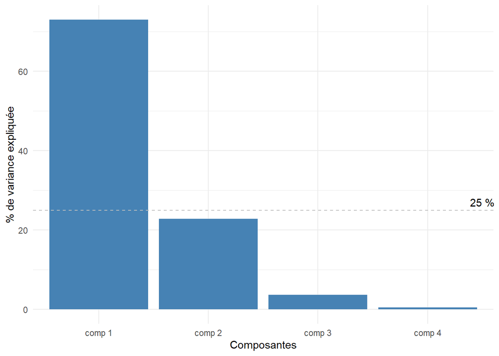

```r
ggplot(eig, aes(comp, percentage.of.variance)) +
  geom_bar(stat = "identity", fill = "steelblue") +
  geom_hline(yintercept = 25, linetype = "dashed", color = "gray") +
  annotate("text", x = 4.5, y = 27, label = "25 %") +
  labs(x = "Composantes", y = "% de variance expliquée") +
  theme_minimal()
```

### Représentation des individus

La représentation directe des individus via la fonction `plot()` n’est pas optimal, mais permet de rapidement voir ce qu’il se passe.

> On remarque ici deux groupes d’iris.

Notez qu’il est d’usage de représenter sur le plan factoriel le pourcentage de variance expliquée.

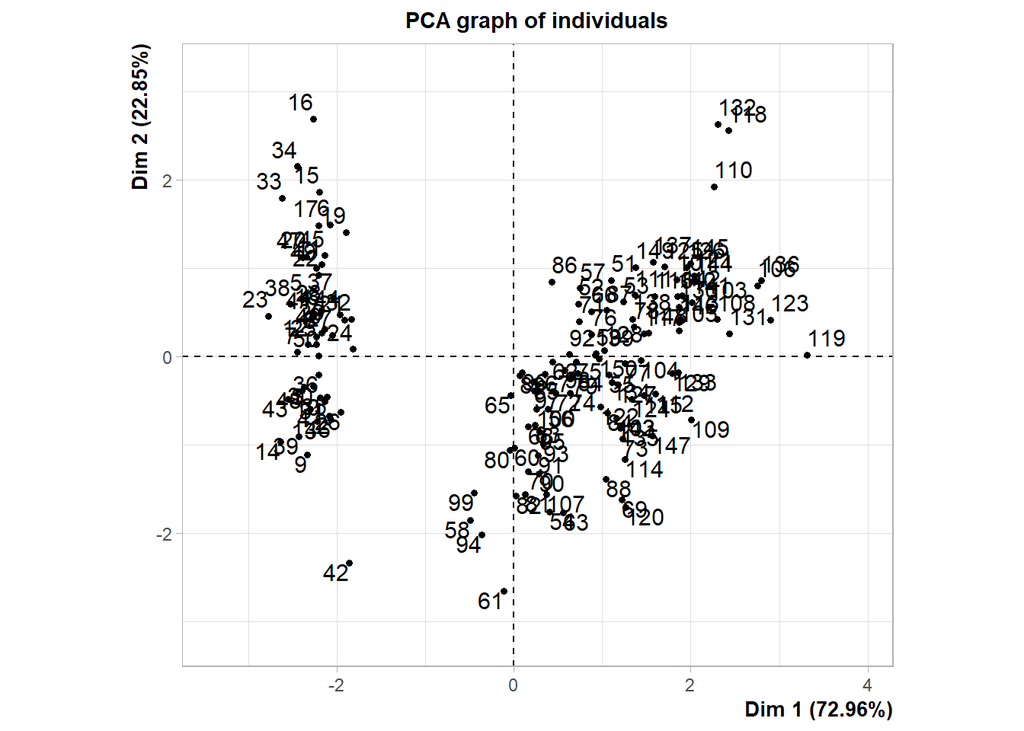

```r
plot(acp, choix = "ind")
```

Les coordonnées obtenues sont contenues dans le sous-dataframe `coord` du sous-objet `ind`. On va s’en servir pour réaliser un graphique plus agréable à lire.

```r
datatable(round(acp$ind$coord, 2))
```

|  | Dim.1 | Dim.2 | Dim.3 | Dim.4 |
| --- | --- | --- | --- | --- |
| 1 | -2.26 | 0.48 | -0.13 | -0.02 |
| 2 | -2.08 | -0.67 | -0.23 | -0.1 |
| 3 | -2.36 | -0.34 | 0.04 | -0.03 |
| 4 | -2.3 | -0.6 | 0.09 | 0.07 |
| 5 | -2.39 | 0.65 | 0.02 | 0.04 |
| 6 | -2.08 | 1.49 | 0.03 | -0.01 |
| 7 | -2.44 | 0.05 | 0.34 | 0.04 |
| 8 | -2.23 | 0.22 | -0.09 | 0.02 |
| 9 | -2.33 | -1.12 | 0.15 | 0.03 |
| 10 | -2.18 | -0.47 | -0.25 | 0.04 |

[output cut: 140 more lines]

En ajoutant l’information sur les espèces (contenue donc dans la variable `Species` du dataframe original), on peut utiliser un nuage de points, avec une couleur en fonction de l’espèce justement.

> On remarque que la méthode sépare très clairement les *setosa* des deux autres espèces (*versicolor* et *virginica*), qui semble être légèrement séparées, mais un peu recouvrantes tout de même.

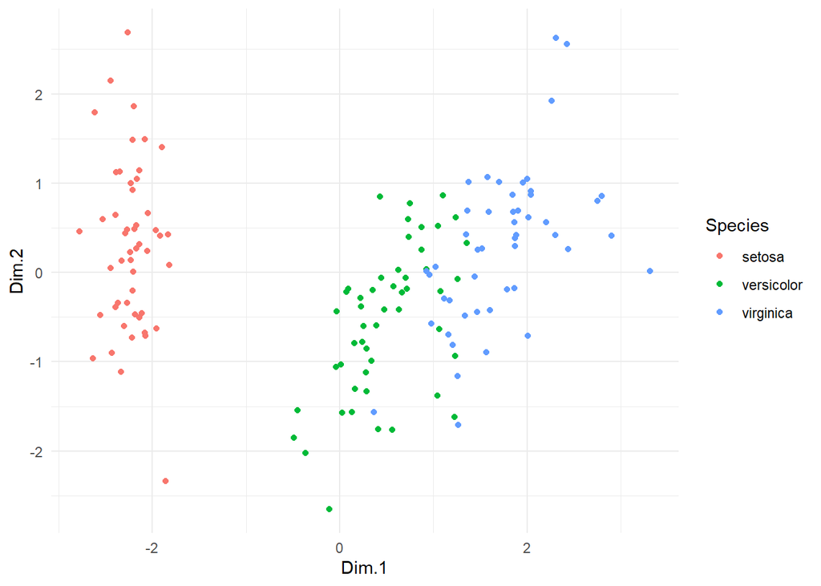

```r
ind = tibble(data.frame(acp$ind$coord)) %>% mutate(Species = iris$Species)
ggplot(ind, aes(Dim.1, Dim.2, color = Species)) +
  geom_point() +
  theme_minimal()
```

### Représentation des variables

Le cercle des corrélations est un outil précieux pour caractériser les axes, afin de mieux comprendre ce qui différencient les éventuels groupes d’individus.

> On voit ici que trois variables sont très proches (longueur de sépale ainsi que largeur et longueur de pétale).

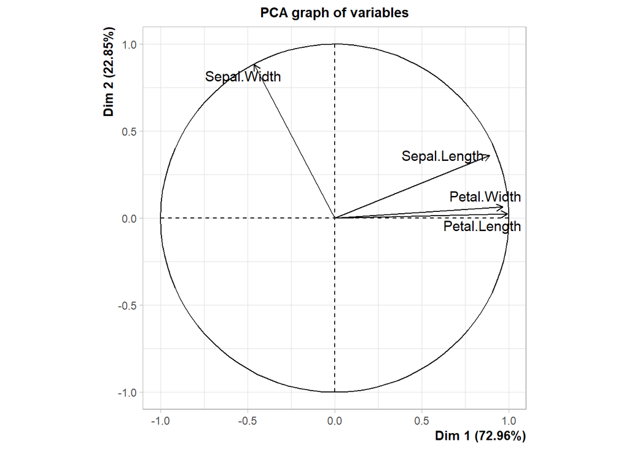

```r
plot(acp, choix = "var")
```

La fonction `dimdesc()` permet de tester les liens entre chaque variable et chaque composante, avec un test de correlation (seule la *p-value* est affichée).

```r
dimdesc(acp)
```

```
## $Dim.1
##
## Link between the variable and the continuous variables (R-square)
## =================================================================================
##              correlation       p.value
## Petal.Length   0.9915552 3.369916e-133
## Petal.Width    0.9649790  6.609632e-88
## Sepal.Length   0.8901688  2.190813e-52
## Sepal.Width   -0.4601427  3.139724e-09
##
## $Dim.2
##
## Link between the variable and the continuous variables (R-square)
## =================================================================================
##              correlation      p.value
## Sepal.Width    0.8827163 2.123801e-50
## Sepal.Length   0.3608299 5.731933e-06
##
## $Dim.3
##
## Link between the variable and the continuous variables (R-square)
## =================================================================================
##              correlation      p.value
## Petal.Width    0.2429827 0.0027349555
## Sepal.Length  -0.2756577 0.0006395628
```

### Caractérisation des axes

A l’aide des informations ci-dessus, il est intéressant de décrire ce que chaque axe *explique*.

> Ici, nous ferions les conclusions suivantes :
- Le premier axe oppose, à droite, les grands iris (grands pétales et longs sépales, mais avec une faible largeur de sépale) aux petits iris à gauche (petits pétales et cours sépales, mais sépales très larges) ;
- Le deuxième axe oppose, en haut, les iris avec des grands sépales aux iris avec petits sépales (en bas) ;
- Le troisième axe expliquant très peu de variance n’est pas à prendre en considération.

## Analyse Factorielle des Correspondances (AFC)

### Données `USAccDeaths`

Nous allons travailler sur des données accidents aux Etats-Unis sur la période 1973-1978, déjà présentes elles-aussi dans R. C’est le nombre de mort par mois, sur la période. Elles sont dans un format spécifique, qu’il faut modifier avant de pouvoir les utiliser avec `FactoMineR`.

```r
Acc = data.frame(matrix(USAccDeaths, ncol = 12, byrow = TRUE, dimnames = list(1973:1978, month.name)))
datatable(Acc, options = list(scrollX = TRUE))
```

|  | January | February | March | April | May | June | July | August | September | October | November | December |
| --- | --- | --- | --- | --- | --- | --- | --- | --- | --- | --- | --- | --- |
| 1973 | 9007 | 8106 | 8928 | 9137 | 10017 | 10826 | 11317 | 10744 | 9713 | 9938 | 9161 | 8927 |
| 1974 | 7750 | 6981 | 8038 | 8422 | 8714 | 9512 | 10120 | 9823 | 8743 | 9129 | 8710 | 8680 |
| 1975 | 8162 | 7306 | 8124 | 7870 | 9387 | 9556 | 10093 | 9620 | 8285 | 8466 | 8160 | 8034 |
| 1976 | 7717 | 7461 | 7767 | 7925 | 8623 | 8945 | 10078 | 9179 | 8037 | 8488 | 7874 | 8647 |
| 1977 | 7792 | 6957 | 7726 | 8106 | 8890 | 9299 | 10625 | 9302 | 8314 | 8850 | 8265 | 8796 |
| 1978 | 7836 | 6892 | 7791 | 8192 | 9115 | 9434 | 10484 | 9827 | 9110 | 9070 | 8633 | 9240 |

### Application de la méthode sur les données

Pour appliquer l’AFC sur le tableau de données, nous utilisons ici la fonction `CA()` (pour *Correspondance Analysis*). Ici aussi, nous choississons de ne pas afficher les graphiques au début.

```r
afc = CA(Acc, graph = FALSE)
```

Comme précédemment, l’objet ainsi créé contient beaucoup d’informations, que nous allons utiliser.

```r
afc
```

```
## **Results of the Correspondence Analysis (CA)**
## The row variable has  6  categories; the column variable has 12 categories
## The chi square of independence between the two variables is equal to 442.9585 (p-value =  5.010401e-62 ).
## *The results are available in the following objects:
##
##    name              description
## 1  "$eig"            "eigenvalues"
## 2  "$col"            "results for the columns"
## 3  "$col$coord"      "coord. for the columns"
## 4  "$col$cos2"       "cos2 for the columns"
## 5  "$col$contrib"    "contributions of the columns"
## 6  "$row"            "results for the rows"
## 7  "$row$coord"      "coord. for the rows"
## 8  "$row$cos2"       "cos2 for the rows"
## 9  "$row$contrib"    "contributions of the rows"
## 10 "$call"           "summary called parameters"
## 11 "$call$marge.col" "weights of the columns"
## 12 "$call$marge.row" "weights of the rows"
```

Comme pour `PCA()`, le résumé permet de voir certains éléments.

```r
summary(afc)
```

```
##
## Call:
## CA(X = Acc, graph = FALSE)
##
## The chi square of independence between the two variables is equal to 442.9585 (p-value =  5.010401e-62 ).
##
## Eigenvalues
##                        Dim.1   Dim.2   Dim.3   Dim.4   Dim.5
## Variance               0.000   0.000   0.000   0.000   0.000
## % of var.             53.754  26.524  10.826   5.384   3.511
## Cumulative % of var.  53.754  80.278  91.105  96.489 100.000
##
## Rows
##             Iner*1000    Dim.1    ctr   cos2    Dim.2    ctr   cos2    Dim.3
## 1973      |     0.103 |  0.017 14.738  0.538 | -0.013 17.228  0.310 |  0.004
## 1974      |     0.094 | -0.014  8.375  0.335 | -0.014 18.584  0.366 |  0.011
## 1975      |     0.170 |  0.030 39.023  0.866 | -0.001  0.053  0.001 | -0.010
## 1976      |     0.117 |  0.003  0.507  0.016 |  0.025 52.096  0.826 |  0.009
## 1977      |     0.068 | -0.012  5.894  0.326 |  0.011 10.236  0.279 | -0.005
## 1978      |     0.148 | -0.027 31.464  0.800 | -0.004  1.802  0.023 | -0.010
##              ctr   cos2
## 1973       4.384  0.032 |
## 1974      27.497  0.221 |
## 1975      20.961  0.094 |
## 1976      18.552  0.120 |
## 1977       5.256  0.058 |
## 1978      23.350  0.120 |
##
## Columns (the 10 first)
##             Iner*1000    Dim.1    ctr   cos2    Dim.2    ctr   cos2    Dim.3
## January   |     0.044 |  0.023 11.075  0.937 |  0.003  0.370  0.015 | -0.005
## February  |     0.121 |  0.030 16.116  0.501 |  0.024 22.211  0.341 |  0.014
## March     |     0.034 |  0.019  7.094  0.784 | -0.001  0.015  0.001 |  0.006
## April     |     0.020 | -0.007  0.899  0.166 | -0.003  0.487  0.044 |  0.013
## May       |     0.061 |  0.018  7.507  0.465 |  0.003  0.411  0.013 | -0.019
## June      |     0.032 |  0.014  4.462  0.523 | -0.012  6.752  0.391 | -0.001
## July      |     0.045 | -0.007  1.162  0.098 |  0.015 11.713  0.487 | -0.007
## August    |     0.017 |  0.001  0.054  0.012 | -0.011  5.832  0.655 |  0.000
## September |     0.064 | -0.015  4.658  0.275 | -0.020 17.147  0.499 | -0.004
## October   |     0.031 | -0.014  4.273  0.526 | -0.008  2.642  0.161 |  0.008
##              ctr   cos2
## January    2.166  0.037 |
## February  18.900  0.118 |
## March      3.794  0.085 |
## April     18.438  0.687 |
## May       40.804  0.509 |
## June       0.148  0.003 |
## July       5.902  0.100 |
## August     0.004  0.000 |
## September  1.526  0.018 |
## October    7.368  0.183 |
```

### Focus sur la part de variance expliquée

On peut reprendre le code précédent, pour l’appliquer directement et voir la part d’inertie expliquée par chaque axe.

> Le premier axe explique un peu plus de la moitié de l’information, et les deux premiers permettent d’expliquer 80% en tout.

```r
eig = tibble(data.frame(afc$eig) %>% rownames_to_column("comp"))
eig
```

```
## # A tibble: 5 × 4
##   comp  eigenvalue percentage.of.variance cumulative.percentage.of.variance
##   <chr>      <dbl>                  <dbl>                             <dbl>
## 1 dim 1  0.000376                   53.8                               53.8
## 2 dim 2  0.000186                   26.5                               80.3
## 3 dim 3  0.0000758                  10.8                               91.1
## 4 dim 4  0.0000377                   5.38                              96.5
## 5 dim 5  0.0000246                   3.51                             100
```

La notion de seuil est moins pertinent en AFC, et on se contentera très souvent (voire tout le temps) de ne garder que deux axes.

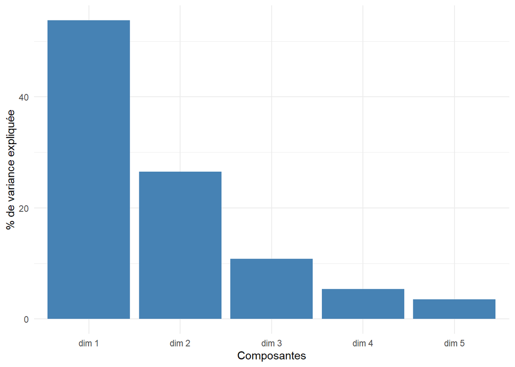

```r
ggplot(eig, aes(comp, percentage.of.variance)) +
  geom_bar(stat = "identity", fill = "steelblue") +
  labs(x = "Composantes", y = "% de variance expliquée") +
  theme_minimal()
```

### Représentation des modalités

Dans une AFC, le but est de représenter graphiquement les modalités de la variable en ligne (ici les années), ainsi que les modalités de la variable en colonnes (ici les mois). On peut créer les graphiques séparément (en rendant l’autre variable *invisible*).

> On a une opposition 1975 vs 1978 sur l’axe 1, et une opposition 1976 vs 1973/1974 sur l’axe 2.

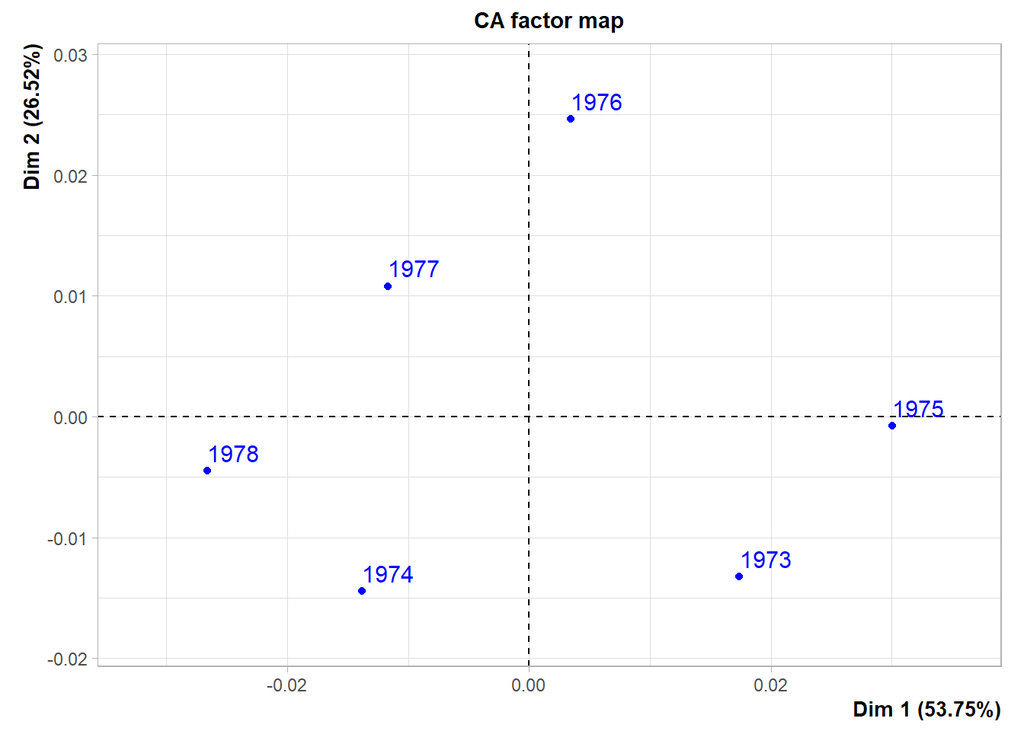

```r
plot(afc, invisible = "col")
```

> Le mois de décembre semble avoir un comportement différent des autres mois, ainsi que Février et Juillet, dans une moindre mesure.

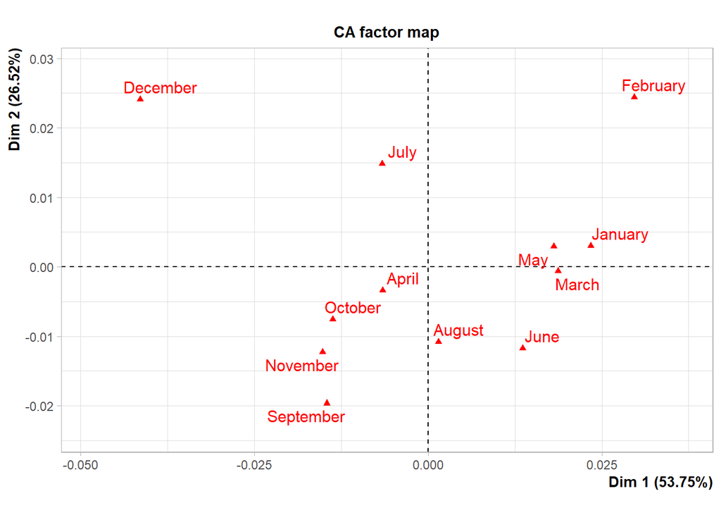

```r
plot(afc, invisible = "row")
```

Mais l’idéal est de représenter les deux directement sur le même graphique afin de relier les modalités des variables entre elles.

> Les mois de Février et Décembre 1976 ont l’air particuliers, ainsi que le mois de juillet 1977 (et 1976).

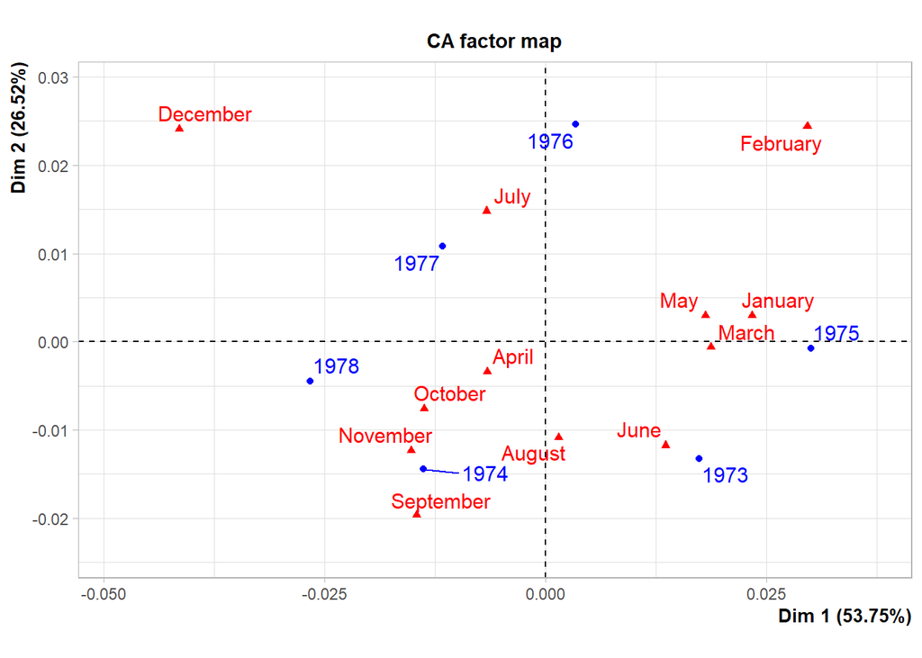

```r
plot(afc)
```

### Si on veut aller plus loin sur ce jeu de données

#### Globalement

- 1973 année la plus mortelle
- Pic de morts en été et au plus bas en février

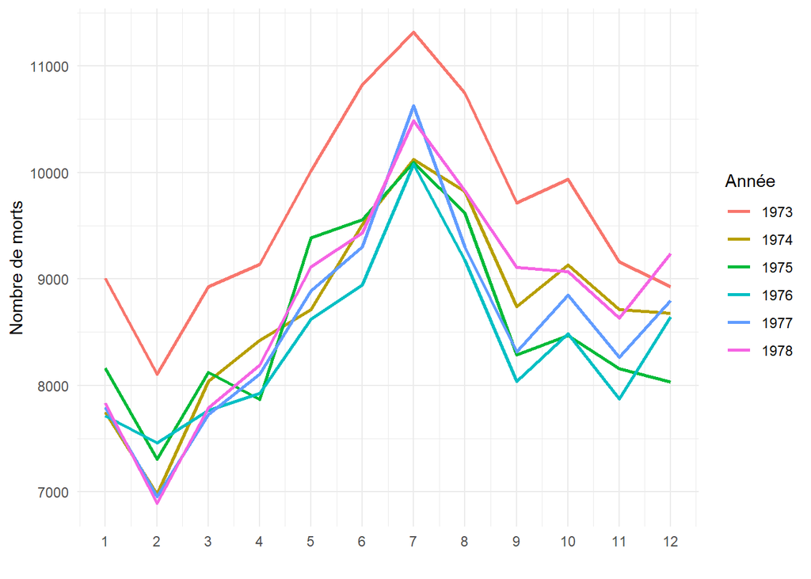

#### Plus finement

- Février 1976 plus haut que *prévu*
- Pour plusieurs mois (janvier, de mars à juin et d’août à décembre,), hausse à partir de 1975 ou 1976

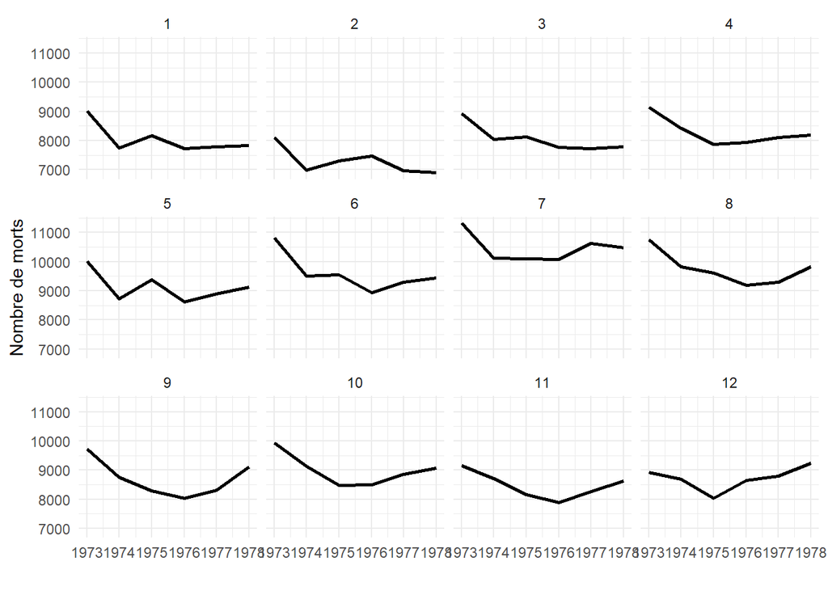

## A FAIRE

### Données `Wine` – ACP

Nous allons travailler sur des données concernant 3 types de vin. Elles sont disponibles sur [cette page](https://archive.ics.uci.edu/ml/datasets/wine) de l’UCI MLR. Il s’agit de 178 vins, réparties en 3 classes donc, et décrit par 13 variables quantitatives (lire la description dans le fichier `wine.names` pour plus d’informations).

Le code suivant permet de charger les données, et de nommer correctement les variables.

```r
wine = read_csv("https://archive.ics.uci.edu/ml/machine-learning-databases/wine/wine.data", col_names = FALSE)
names(wine) = c("class", "Alcohol", "Malic acid", "Ash", "Alcalinity of ash", "Magnesium",
                "Total phenols", "Flavanoids", "Nonflavanoid phenols", "Proanthocyanins",
                "Color intensity", "Hue", "OD280/OD315 of diluted wines", "Proline")
datatable(wine, options = list(scrollX = TRUE))
```

|  | class | Alcohol | Malic acid | Ash | Alcalinity of ash | Magnesium | Total phenols | Flavanoids | Nonflavanoid phenols | Proanthocyanins | Color intensity | Hue | OD280/OD315 of diluted wines | Proline |
| --- | --- | --- | --- | --- | --- | --- | --- | --- | --- | --- | --- | --- | --- | --- |
| 1 | 1 | 14.23 | 1.71 | 2.43 | 15.6 | 127 | 2.8 | 3.06 | 0.28 | 2.29 | 5.64 | 1.04 | 3.92 | 1065 |
| 2 | 1 | 13.2 | 1.78 | 2.14 | 11.2 | 100 | 2.65 | 2.76 | 0.26 | 1.28 | 4.38 | 1.05 | 3.4 | 1050 |
| 3 | 1 | 13.16 | 2.36 | 2.67 | 18.6 | 101 | 2.8 | 3.24 | 0.3 | 2.81 | 5.68 | 1.03 | 3.17 | 1185 |
| 4 | 1 | 14.37 | 1.95 | 2.5 | 16.8 | 113 | 3.85 | 3.49 | 0.24 | 2.18 | 7.8 | 0.86 | 3.45 | 1480 |
| 5 | 1 | 13.24 | 2.59 | 2.87 | 21 | 118 | 2.8 | 2.69 | 0.39 | 1.82 | 4.32 | 1.04 | 2.93 | 735 |
| 6 | 1 | 14.2 | 1.76 | 2.45 | 15.2 | 112 | 3.27 | 3.39 | 0.34 | 1.97 | 6.75 | 1.05 | 2.85 | 1450 |
| 7 | 1 | 14.39 | 1.87 | 2.45 | 14.6 | 96 | 2.5 | 2.52 | 0.3 | 1.98 | 5.25 | 1.02 | 3.58 | 1290 |
| 8 | 1 | 14.06 | 2.15 | 2.61 | 17.6 | 121 | 2.6 | 2.51 | 0.31 | 1.25 | 5.05 | 1.06 | 3.58 | 1295 |
| 9 | 1 | 14.83 | 1.64 | 2.17 | 14 | 97 | 2.8 | 2.98 | 0.29 | 1.98 | 5.2 | 1.08 | 2.85 | 1045 |
| 10 | 1 | 13.86 | 1.35 | 2.27 | 16 | 98 | 2.98 | 3.15 | 0.22 | 1.85 | 7.22 | 1.01 | 3.55 | 1045 |

[output cut: 168 more lines]

Vous devez donc réaliser les étapes suivantes :

- Décrire les données
- Réaliser une ACP centrée ou normée (choix à justifier)
- Produire les graphiques nécessaires à l’interprétation
- Identifier les classes sur le plan factoriel
- Que peut-on dire globalement ?

### Données CSP 1968 et 2014 – AFC

Nous disposons sur cette page de la répartition de la population active de 25 à 54 ans selon la catégorie socioprofessionnelle et la position vis à vis de l’emploi, par commune et département, de [1968](https://fxjollois.github.io/donnees/regions-csp/regions-csp-1968.csv) et de [2014](https://fxjollois.github.io/donnees/regions-csp/regions-csp-2014.csv).

Les codes ci-dessous vous montrent comment les importer (en supprimant les données sur les chômeurs).

```r
regions1968 = read_csv("https://fxjollois.github.io/donnees/regions-csp/regions-csp-1968.csv") %>%
  select(!contains("Chômeurs")) %>%
  column_to_rownames("Région")
names(regions1968) = sub(" RP1968", "", names(regions1968))
datatable(regions1968, options = list(scrollX = TRUE))
```

|  | Agriculteurs Actifs ayant un emploi | Artisans, commerçants, chefs d'entreprise Actifs ayant un emploi | Cadres et professions intellectuelles supérieures Actifs ayant un emploi | Professions intermédiaires Actifs ayant un emploi | Employés Actifs ayant un emploi | Ouvriers Actifs ayant un emploi |
| --- | --- | --- | --- | --- | --- | --- |
| Île-de-France | 13652 | 221520 | 305912 | 521652 | 791704 | 879892 |
| Centre-Val de Loire | 73128 | 53572 | 21604 | 59452 | 85424 | 183304 |
| Bourgogne-Franche-Comté | 85284 | 61824 | 26604 | 76732 | 103348 | 231496 |
| Normandie | 113008 | 69388 | 30088 | 86712 | 113204 | 256920 |
| Hauts-de-France | 86004 | 119944 | 53872 | 160128 | 197596 | 541364 |
| Grand Est | 97980 | 96348 | 62796 | 159032 | 215492 | 516920 |
| Pays de la Loire | 151212 | 67008 | 23992 | 70120 | 94472 | 206432 |
| Bretagne | 181764 | 70200 | 24464 | 60080 | 87700 | 180328 |
| Nouvelle-Aquitaine | 226852 | 129596 | 50772 | 119248 | 201232 | 365672 |
| Occitanie | 143432 | 102208 | 46608 | 110108 | 161756 | 300480 |

[output cut: 3 more lines]

```r
regions2014 = read_csv("https://fxjollois.github.io/donnees/regions-csp/regions-csp-2014.csv") %>%
  select(!contains("Chômeurs")) %>%
  column_to_rownames("Région")
names(regions2014) = sub(" RP2014", "", names(regions2014))
datatable(round(regions2014), options = list(scrollX = TRUE))
```

|  | Agriculteurs Actifs ayant un emploi | Artisans, commerçants, chefs d'entreprise Actifs ayant un emploi | Cadres et professions intellectuelles supérieures Actifs ayant un emploi | Professions intermédiaires Actifs ayant un emploi | Employés Actifs ayant un emploi | Ouvriers Actifs ayant un emploi |
| --- | --- | --- | --- | --- | --- | --- |
| Île-de-France | 3373 | 203748 | 1287917 | 1095707 | 1017211 | 521635 |
| Centre-Val de Loire | 13731 | 47577 | 108799 | 210089 | 218766 | 184517 |
| Bourgogne-Franche-Comté | 20315 | 53730 | 105346 | 221857 | 227163 | 219598 |
| Normandie | 19266 | 61808 | 125731 | 265518 | 279645 | 250432 |
| Hauts-de-France | 17767 | 87398 | 248085 | 472126 | 499289 | 436389 |
| Grand Est | 25048 | 90645 | 239531 | 450269 | 477570 | 432458 |
| Pays de la Loire | 28430 | 72191 | 166422 | 310325 | 304497 | 288690 |
| Bretagne | 27349 | 67632 | 145135 | 267530 | 268943 | 231276 |
| Nouvelle-Aquitaine | 46102 | 135544 | 239035 | 457809 | 502339 | 378054 |
| Occitanie | 40228 | 138923 | 280740 | 456963 | 461749 | 291517 |

[output cut: 3 more lines]

- Réaliser une AFC sur le croisement entre la catégorie socioprofessionnelle et la région
  - pour 1968
  - pour 2014
- A l’aide des outils à votre disposition (tableaux et graphiques),
  - Décrire la situation pour chaque année,
  - Comparer les deux situations